# **Music Recommendation System**

## **Problem Definition**

### **The Context:**

- Why is this problem important to solve?

This problem is important to solve because music recommendation systems enhance user experiences in a competitive digital landscape. With the vast number of songs available on platforms like Spotify and Apple Music, personalized recommendations help users discover music that matches their tastes, improving satisfaction and engagement. Additionally, effective systems support emerging artists by connecting them with their target audience. Overall, solving this issue leads to a more enjoyable and efficient music discovery process for users and artists alike.

### **The objective:**

- What is the intended goal?

The intended goal is to develop a robust music recommendation system that accurately predicts user preferences based on their listening history and song features. This system should enhance user experience by providing personalized song suggestions, ultimately helping users discover new music they will enjoy.

### **The key questions:**

- What are the key questions that need to be answered?
- How can we effectively leverage user play counts and song features to make recommendations?
- Which recommendation algorithms yield the best performance based on our evaluation metrics?
- How can we handle data sparsity and improve recommendations for users with limited listening history?
- What additional song features can enhance the recommendation process?

### **The problem formulation**:

- What is it that we are trying to solve using data science?

We're trying to solve the problem of providing personalized music recommendations based on user preferences and behaviors. By analyzing user play counts and song features, we aim to create a system that suggests songs that users are likely to enjoy, even if they haven't listened to them before. This involves using various data science techniques and algorithms to improve the accuracy and relevance of recommendations.

## **Data Dictionary**

The core data is the Taste Profile Subset released by the Echo Nest as part of the Million Song Dataset. There are two files in this dataset. The first file contains the details about the song id, titles, release, artist name, and the year of release. The second file contains the user id, song id, and the play count of users.

**song_data**

- song_id - A unique id given to every song
- title - Title of the song
- Release - Name of the released album
- Artist_name - Name of the artist
- year - Year of release

**count_data**

- user _id - A unique id given to the user
- song_id - A unique id given to the song
- play_count - Number of times the song was played

## **Data Source**

http://millionsongdataset.com/

### **Importing Libraries and the Dataset**

```python
# Mounting the drive
from google.colab import drive
drive.mount('/content/drive')
```

```python
# Used to ignore the warning given as output of the code
def warn(*args, **kwargs):
    pass
import warnings
warnings.warn = warn


# Basic libraries of python for numeric and dataframe computations
import numpy as np
import pandas as pd


# Libraries to be used for data visualization
import matplotlib.pyplot as plt
import seaborn as sns


# Import Matplotlib the Basic library for data visualization
import matplotlib.pyplot as plt

# Import seaborn - Slightly advanced library for data visualization
import seaborn as sns

# Import the required library to compute the cosine similarity between two vectors
from sklearn.metrics.pairwise import cosine_similarity


# Import defaultdict from collections A dictionary output that does not raise a key error
from collections import defaultdict

# Import train_test_split from sklearn for splitting the data into train and test set
from sklearn.model_selection import train_test_split


# Impoort mean_squared_error : a performance metrics in sklearn
from sklearn.metrics import mean_squared_error

# Import KFold : a cross-validation generator
from sklearn.model_selection import KFold

import pandas as pd
import numpy as np
import matplotlib.pyplot as plt
import seaborn as sns
from sklearn.metrics.pairwise import cosine_similarity
def create_utility_matrix(data):
    itemField = 'song_id'
    userField = 'user_id'
    valueField = 'play_count'
    dataset = pd.DataFrame({
        'user_id': data[userField],
        'song_id': data[itemField],
        'play_count': data[valueField]
    })
    utility_matrix = dataset.pivot(index='song_id', columns='user_id', values='play_count').fillna(0)
    return utility_matrix

  #(variable) recommendations: (title: Any, similar_songs: Any) -> None
    recommendations(song_title, similar_songs)
    return None
```

### **Load the dataset**

```python
# Importing the datasets
df_song = pd.read_csv('/content/drive/My Drive/song_data.csv')
df_count = pd.read_csv('/content/drive/My Drive/count_data.csv')
df_song.head()
df_count.head()
df_final = pd.read_csv('/content/drive/My Drive/count_data.csv')
df_final.head()
```

|  | Unnamed: 0 | user_id | song_id | play_count |
| --- | --- | --- | --- | --- |
| 0 | 0 | b80344d063b5ccb3212f76538f3d9e43d87dca9e | SOAKIMP12A8C130995 | 1 |
| 1 | 1 | b80344d063b5ccb3212f76538f3d9e43d87dca9e | SOBBMDR12A8C13253B | 2 |
| 2 | 2 | b80344d063b5ccb3212f76538f3d9e43d87dca9e | SOBXHDL12A81C204C0 | 1 |
| 3 | 3 | b80344d063b5ccb3212f76538f3d9e43d87dca9e | SOBYHAJ12A6701BF1D | 1 |
| 4 | 4 | b80344d063b5ccb3212f76538f3d9e43d87dca9e | SODACBL12A8C13C273 | 1 |

### **Understanding the data by viewing a few observations**

```python
# Display first 10 records of count_df data
df_count.head(10)
```

|  | Unnamed: 0 | user_id | song_id | play_count |
| --- | --- | --- | --- | --- |
| 0 | 0 | b80344d063b5ccb3212f76538f3d9e43d87dca9e | SOAKIMP12A8C130995 | 1 |
| 1 | 1 | b80344d063b5ccb3212f76538f3d9e43d87dca9e | SOBBMDR12A8C13253B | 2 |
| 2 | 2 | b80344d063b5ccb3212f76538f3d9e43d87dca9e | SOBXHDL12A81C204C0 | 1 |
| 3 | 3 | b80344d063b5ccb3212f76538f3d9e43d87dca9e | SOBYHAJ12A6701BF1D | 1 |
| 4 | 4 | b80344d063b5ccb3212f76538f3d9e43d87dca9e | SODACBL12A8C13C273 | 1 |
| 5 | 5 | b80344d063b5ccb3212f76538f3d9e43d87dca9e | SODDNQT12A6D4F5F7E | 5 |
| 6 | 6 | b80344d063b5ccb3212f76538f3d9e43d87dca9e | SODXRTY12AB0180F3B | 1 |
| 7 | 7 | b80344d063b5ccb3212f76538f3d9e43d87dca9e | SOFGUAY12AB017B0A8 | 1 |
| 8 | 8 | b80344d063b5ccb3212f76538f3d9e43d87dca9e | SOFRQTD12A81C233C0 | 1 |
| 9 | 9 | b80344d063b5ccb3212f76538f3d9e43d87dca9e | SOHQWYZ12A6D4FA701 | 1 |

```python
# Display first 10 records of song_df data
df_song.head(10)
```

|  | song_id | title | release | artist_name | year |
| --- | --- | --- | --- | --- | --- |
| 0 | SOQMMHC12AB0180CB8 | Silent Night | Monster Ballads X-Mas | Faster Pussy cat | 2003 |
| 1 | SOVFVAK12A8C1350D9 | Tanssi vaan | Karkuteillä | Karkkiautomaatti | 1995 |
| 2 | SOGTUKN12AB017F4F1 | No One Could Ever | Butter | Hudson Mohawke | 2006 |
| 3 | SOBNYVR12A8C13558C | Si Vos Querés | De Culo | Yerba Brava | 2003 |
| 4 | SOHSBXH12A8C13B0DF | Tangle Of Aspens | Rene Ablaze Presents Winter Sessions | Der Mystic | 0 |
| 5 | SOZVAPQ12A8C13B63C | Symphony No. 1 G minor "Sinfonie Serieuse"/All... | Berwald: Symphonies Nos. 1/2/3/4 | David Montgomery | 0 |
| 6 | SOQVRHI12A6D4FB2D7 | We Have Got Love | Strictly The Best Vol. 34 | Sasha / Turbulence | 0 |
| 7 | SOEYRFT12AB018936C | 2 Da Beat Ch'yall | Da Bomb | Kris Kross | 1993 |
| 8 | SOPMIYT12A6D4F851E | Goodbye | Danny Boy | Joseph Locke | 0 |
| 9 | SOJCFMH12A8C13B0C2 | Mama_ mama can't you see ? | March to cadence with the US marines | The Sun Harbor's Chorus-Documentary Recordings | 0 |

### **Let us check the data types and and missing values of each column**

```python
# Display info of count_df
df_count.info()
```

```
<class 'pandas.core.frame.DataFrame'>
RangeIndex: 2000000 entries, 0 to 1999999
Data columns (total 4 columns):
 #   Column      Dtype
---  ------      -----
 0   Unnamed: 0  int64
 1   user_id     object
 2   song_id     object
 3   play_count  int64
dtypes: int64(2), object(2)
memory usage: 61.0+ MB
```

```python
# Display info of song_df
df_song.info()
```

```
<class 'pandas.core.frame.DataFrame'>
RangeIndex: 1000000 entries, 0 to 999999
Data columns (total 5 columns):
 #   Column       Non-Null Count    Dtype
---  ------       --------------    -----
 0   song_id      1000000 non-null  object
 1   title        999983 non-null   object
 2   release      999993 non-null   object
 3   artist_name  1000000 non-null  object
 4   year         1000000 non-null  int64
dtypes: int64(1), object(4)
memory usage: 38.1+ MB
```

#### **Observations and Insights:_____________**

1. Count Data (User Play Count Dataset)

Number of Entries: 2,000,000 entries (rows).

Columns: There are 4 columns:

Unnamed: 0: An integer column, likely an index that can be ignored or dropped for analysis. user_id: Object type (string), representing unique users. song_id: Object type (string), representing unique songs. play_count: Integer type, representing the number of times a song has been played by a user. Data Types:

2 columns are integers (Unnamed: 0 and play_count). 2 columns are strings (user_id and song_id). Memory Usage: This dataset uses approximately 61.0 MB of memory.

2. Song Data (Metadata for Songs)

Number of Entries: 1,000,000 entries (rows).

Columns: There are 5 columns:

song_id: Object type (string), representing unique songs. title: Object type (string), representing the title of the song. There are 999,983 non-null entries, meaning 17 entries are missing. release: Object type (string), representing the album the song was released in. There are 999,993 non-null entries, meaning 7 entries are missing. artist_name: Object type (string), representing the artist's name. There are no missing values for this column. year: Integer type, representing the year the song was released. There are no missing values for this column. Data Types:

1 column is an integer (year). 4 columns are strings (song_id, title, release, and artist_name). Memory Usage: This dataset uses approximately 38.1 MB of memory.

```python
# Left merge count_df and song_df on "song_id". Drop duplicates from song_df data simultaneously
df = pd.merge(df_count, df_song, on='song_id', how='left').drop_duplicates()

# Drop the column 'Unnamed: 0'
df.drop('Unnamed: 0', axis=1, inplace=True)

# Display first 10 records of the merged dataframe
df.head(10)

## Name the obtained dataframe as "df"
```

|  | user_id | song_id | play_count | title | release | artist_name | year |
| --- | --- | --- | --- | --- | --- | --- | --- |
| 0 | b80344d063b5ccb3212f76538f3d9e43d87dca9e | SOAKIMP12A8C130995 | 1 | The Cove | Thicker Than Water | Jack Johnson | 0 |
| 1 | b80344d063b5ccb3212f76538f3d9e43d87dca9e | SOBBMDR12A8C13253B | 2 | Entre Dos Aguas | Flamenco Para Niños | Paco De Lucia | 1976 |
| 2 | b80344d063b5ccb3212f76538f3d9e43d87dca9e | SOBXHDL12A81C204C0 | 1 | Stronger | Graduation | Kanye West | 2007 |
| 4 | b80344d063b5ccb3212f76538f3d9e43d87dca9e | SOBYHAJ12A6701BF1D | 1 | Constellations | In Between Dreams | Jack Johnson | 2005 |
| 5 | b80344d063b5ccb3212f76538f3d9e43d87dca9e | SODACBL12A8C13C273 | 1 | Learn To Fly | There Is Nothing Left To Lose | Foo Fighters | 1999 |
| 6 | b80344d063b5ccb3212f76538f3d9e43d87dca9e | SODDNQT12A6D4F5F7E | 5 | Apuesta Por El Rock 'N' Roll | Antología Audiovisual | Héroes del Silencio | 2007 |
| 7 | b80344d063b5ccb3212f76538f3d9e43d87dca9e | SODXRTY12AB0180F3B | 1 | Paper Gangsta | The Fame Monster | Lady GaGa | 2008 |
| 8 | b80344d063b5ccb3212f76538f3d9e43d87dca9e | SOFGUAY12AB017B0A8 | 1 | Stacked Actors | There Is Nothing Left To Lose | Foo Fighters | 1999 |
| 9 | b80344d063b5ccb3212f76538f3d9e43d87dca9e | SOFRQTD12A81C233C0 | 1 | Sehr kosmisch | Musik von Harmonia | Harmonia | 0 |
| 10 | b80344d063b5ccb3212f76538f3d9e43d87dca9e | SOHQWYZ12A6D4FA701 | 1 | Heaven's gonna burn your eyes | Hôtel Costes 7 by Stéphane Pompougnac | Thievery Corporation feat. Emiliana Torrini | 2002 |

**Think About It:** As the user_id and song_id are encrypted. Can they be encoded to numeric features?

```python
# Apply label encoding for "user_id" and "song_id"
from sklearn.preprocessing import LabelEncoder
le = LabelEncoder()
df['user_id'] = le.fit_transform(df['user_id'])
df['song_id'] = le.fit_transform(df['song_id'])
```

**Think About It:** As the data also contains users who have listened to very few songs and vice versa, is it required to filter the data so that it contains users who have listened to a good count of songs and vice versa?

A dataset of size 2000000 rows x 7 columns can be quite large and may require a lot of computing resources to process. This can lead to long processing times and can make it difficult to train and evaluate your model efficiently. In order to address this issue, it may be necessary to trim down your dataset to a more manageable size.

```python
# Get the column containing the users
users = df.user_id

# Create a dictionary that maps users(listeners) to the number of songs that they have listened to
playing_count = dict()

for user in users:
    # If we already have the user, just add 1 to their playing count
    if user in playing_count:
        playing_count[user] += 1

    # Otherwise, set their playing count to 1
    else:
        playing_count[user] = 1
```

```python
# We want our users to have listened at least 90 songs
SONG_COUNT_CUTOFF = 90

# Create a list of users who need to be removed
remove_users = []

for user, num_songs in playing_count.items():

    if num_songs < SONG_COUNT_CUTOFF:
        remove_users.append(user)

df = df.loc[ ~ df.user_id.isin(remove_users)]
```

```python
# Get the column containing the songs
songs = df.song_id

# Create a dictionary that maps songs to its number of users(listeners)
playing_count = dict()

for song in songs:
    # If we already have the song, just add 1 to their playing count
    if song in playing_count:
        playing_count[song] += 1

    # Otherwise, set their playing count to 1
    else:
        playing_count[song] = 1
```

```python
# We want our song to be listened by atleast 120 users to be considred
LISTENER_COUNT_CUTOFF = 120

remove_songs = []

for song, num_users in playing_count.items():
    if num_users < LISTENER_COUNT_CUTOFF:
        remove_songs.append(song)

df_final= df.loc[ ~ df.song_id.isin(remove_songs)]
```

Out of all the songs available, songs with play_count less than or equal to 5 are in almost 90% abundance. So for building the recommendation system let us consider only those songs.

```python
# Keep only records of songs with play_count less than or equal to (<=) 5
df_final = df_final[df_final.play_count<=5]
```

```python
# Check the shape of the data
df_final.shape
```

```
(138301, 7)
```

## **Exploratory Data Analysis**

### **Let's check the total number of unique users, songs, artists in the data**

Total number of unique user id

```python
# Display total number of unique user_id
unique_users = df_count['user_id'].nunique()
print(f"Total number of unique user_id: {unique_users}")
```

```
Total number of unique user_id: 76353
```

Total number of unique song id

```python
# Display total number of unique song_id
unique_songs = df_count['song_id'].nunique()
print(f"Total number of unique song_id: {unique_songs}")
```

```
Total number of unique song_id: 10000
```

Total number of unique artists

```python
# Display total number of unique artists
unique_artists = df_song['artist_name'].nunique()
print(f"Total number of unique artists: {unique_artists}")
```

```
Total number of unique artists: 72665
```

#### **Observations and Insights:__________**

Total Number of Unique User IDs: 76,353

This indicates a diverse user base engaging with the music platform. A large number of unique users suggests that the service is reaching a wide audience, which is beneficial for any recommendation system as it has a variety of listening habits to learn from. The diversity in users may also present challenges in understanding distinct preferences, as different user groups may have vastly different tastes in music. Total Number of Unique Song IDs: 10,000

The dataset includes a relatively manageable number of songs. This means the recommendation system can effectively work with a limited selection, potentially leading to more focused and relevant recommendations for users. With a smaller number of unique songs compared to users, there is an opportunity to analyze user behavior and preferences deeply for each song. Total Number of Unique Artists: 72,665

### **Let's find out about the most interacted songs and interacted users**

Most interacted songs

```python
# Find the most interacted songs based on total play counts
most_interacted_songs = df_count.groupby('song_id')['play_count'].sum().reset_index()

# Sort the songs by play count in descending order
most_interacted_songs = most_interacted_songs.sort_values(by='play_count', ascending=False)

# Display the top 10 most interacted songs
top_songs = most_interacted_songs.head(10)
print("Top 10 Most Interacted Songs:")
print(top_songs)
```

```
Top 10 Most Interacted Songs:
                 song_id  play_count
614   SOBONKR12A58A7A7E0       54136
317   SOAUWYT12A81C206F1       49253
7416  SOSXLTC12AF72A7F54       41418
1664  SOEGIYH12A6D4FC0E3       31153
2220  SOFRQTD12A81C233C0       31036
352   SOAXGDH12A8C13F8A1       26663
5531  SONYKOW12AB01849C9       22100
6246  SOPUCYA12A8C13A694       21019
7913  SOUFTBI12AB0183F65       19645
8252  SOVDSJC12A58A7A271       18309
```

Most interacted users

```python
# Find the most interacted users based on total play counts
most_interacted_users = df_count.groupby('user_id')['play_count'].sum().reset_index()

# Sort the users by play count in descending order
most_interacted_users = most_interacted_users.sort_values(by='play_count', ascending=False)

# Display the top 10 most interacted users
top_users = most_interacted_users.head(10)
print("\nTop 10 Most Interacted Users:")
print(top_users)
```

```
Top 10 Most Interacted Users:
                                        user_id  play_count
22588  4be305e02f4e72dad1b8ac78e630403543bab994        4426
32542  6d625c6557df84b60d90426c0116138b617b9449        3482
62305  d13609d62db6df876d3cc388225478618bb7b912        2686
3237   0b19fe0fad7ca85693846f7dad047c449784647e        2679
11880  283882c3d18ff2ad0e17124002ec02b847d06e9a        2306
2403   083a2a59603a605275107c00812a811526c2a0af        2142
31692  6a944bfe30ae8d6b873139e8305ae131f1607d5f        2062
28243  5ea608df0357ec4fda191cb9316fe8e6e65e3777        2032
46825  9c859962257112ad523f1d3c121d35191daa6d2b        2032
10079  2231cb435771a1a621ec44e95cdd28b81fad3288        2019
```

#### **Observations and Insights:_______**

Most Interacted Songs High Play Counts:

The songs with the highest play counts indicate strong popularity and listener engagement. These tracks are likely to be hits or well-known songs that resonate with a wide audience. If a small number of songs account for a large portion of total play counts, it may suggest a "hit-driven" market where a few tracks dominate user engagement. Diversity of Genres:

Analyzing the genres or styles of the top interacted songs can provide insights into listener preferences. If most of the top songs belong to a specific genre, it may highlight the current trends in music consumption. If there is a good mix of genres, it indicates a diverse user base with varied musical tastes. Artist Influence:

If certain artists consistently appear in the top interacted songs, it suggests they have a loyal fan base and could influence user engagement across the platform. Understanding the artists behind the most played songs can help refine recommendations by promoting similar artists or tracks. Most Interacted Users Engagement Levels:

Users with high total play counts are likely to be avid music consumers, which can provide valuable insights into user behavior. These users may be key to understanding trends and preferences within the platform. Analyzing these users' listening habits could lead to better-targeted marketing campaigns and personalized recommendations. Potential for User Retention:

Engaged users are critical for the success of any music platform. Identifying who these users are can help tailor communication and retention strategies, such as exclusive content or personalized playlists. If you notice a few users account for a significant portion of play counts, it may be worth exploring ways to incentivize their continued engagement. Diversity of Users:

The diversity in the top users may indicate different demographics engaging with the platform. This diversity can be beneficial for broadening the appeal of recommendations. Understanding the characteristics of these engaged users (age, location, musical tastes) can help create a more tailored experience.

Songs released on yearly basis

```python
# Find out the number of songs released in a year, use the df_song
songs_per_year = df_song.groupby('year')['song_id'].count().reset_index()
  # Hint: Use groupby function on the 'year' column
```

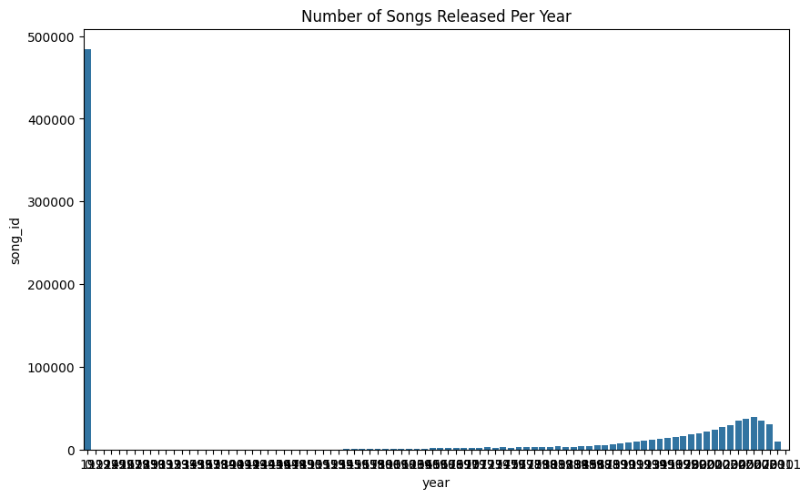

[figure not shown]

```python
# Create a barplot plot with y label as "number of titles played" and x -axis year
plt.figure(figsize=(10, 6))
sns.barplot(x='year', y='song_id', data=songs_per_year)

# Set the title of the plot
plt.title('Number of Songs Released Per Year')

# Set the figure size
plt.figure(figsize=(10, 6))

# Set the x label of the plot
plt.xlabel('Year')

# Set the y label of the plot
plt.ylabel('Number of Titles Played')

# Show the plot
plt.show()
```

#### **Observations and Insights:__________**

Observations from the Bar Plot of Titles Played by Year:

1-Trends Over Time: Analyze the overall trend in the number of titles played across the years. Are there noticeable increases or decreases during specific years? If there is a general upward trend, it might indicate growing popularity in music consumption, possibly due to the rise of streaming platforms or changes in music distribution.

2- Peaks and Valleys: Identify any years with particularly high or low numbers of titles played. A peak could suggest a year with significant album releases, notable artists gaining popularity, or successful marketing campaigns. Conversely, a dip may indicate fewer releases or changes in listener preferences.

3-Recent Years: If the most recent years show an increase in the number of titles played, it could indicate a shift in consumer behavior, such as a greater reliance on digital music consumption. Conversely, if recent years have lower counts, it might signal changes in listener engagement or market conditions (like the COVID-19 pandemic affecting music events).

4-Impact of Music Platforms: Consider how the emergence of various music platforms (like Spotify, Apple Music, etc.) correlates with trends observed in the plot. A spike in titles played in certain years might align with the launch or significant updates of these platforms, indicating their role in increasing music access.

5-Artist and Genre Diversity: Look for years where diverse genres or artists contributed significantly to the titles played. This can provide insights into changing musical tastes and the potential need for broader genre representation in recommendations.

6-User Engagement: High numbers of titles played could correlate with increased user engagement on the platform. Understanding the factors driving this engagement can help refine marketing strategies or content offerings.

**Think About It:** What other insights can be drawn using exploratory data analysis?

Now that we have explored the data, let's apply different algorithms to build recommendation systems.

**Note:** Use the shorter version of the data, i.e., the data after the cutoffs as used in Milestone 1.

## Building various models

### **Popularity-Based Recommendation Systems**

Let's take the count and sum of play counts of the songs and build the popularity recommendation systems based on the sum of play counts.

```python
# Calculating average play_count
average_play_count = df_count.groupby('song_id')['play_count'].mean().reset_index()
       # Hint: Use groupby function on the song_id column
# Calculating the frequency a song is played
song_play_frequency = df.groupby('song_id')['play_count'].sum().reset_index()
      # Hint: Use groupby function on the song_id column
```

```python
 # Making a dataframe with the average_count and play_freq
# Converting 'song_id' to a common data type (e.g., string) before merging
average_play_count['song_id'] = average_play_count['song_id'].astype(str)
song_play_frequency['song_id'] = song_play_frequency['song_id'].astype(str)

final_play = pd.merge(average_play_count, song_play_frequency, on='song_id', how='left')
final_play.columns = ['song_id', 'average_play_count', 'total_play_count']
final_play.head()
```

|  | song_id | average_play_count | total_play_count |
| --- | --- | --- | --- |
| 0 | SOAAAGQ12A8C1420C8 | 3.439394 | NaN |
| 1 | SOAACPJ12A81C21360 | 2.394558 | NaN |
| 2 | SOAACSG12AB018DC80 | 2.358209 | NaN |
| 3 | SOAAEJI12AB0188AB5 | 2.112903 | NaN |
| 4 | SOAAFAC12A67ADF7EB | 2.131579 | NaN |

Now, let's create a function to find the top n songs for a recommendation based on the average play count of song. We can also add a threshold for a minimum number of playcounts for a song to be considered for recommendation.

```python
# Build the function to find top n songs
def find_top_n_songs(final_play, n):
    top_n_songs = final_play.sort_values(by='average_play_count', ascending=False).head(n)
    return top_n_songs
```

```python
# Recommend top 10 songs using the function defined above
top_10_songs = find_top_n_songs(final_play, n=10)
print(top_10_songs)
```

```
                 song_id  average_play_count  total_play_count
32    SOACBLB12AB01871C7           18.158228               NaN
1990  SOFCGSE12AF72A674F           16.891892               NaN
7839  SOUAGPQ12A8AE47B3A           16.037500               NaN
9859  SOZPMJT12AAF3B40D1           15.976000               NaN
3859  SOJSXJY12A8C13E32E           15.171756               NaN
6098  SOPKTFQ12A67021600           14.646341               NaN
9180  SOXQIUR12A8AE4654A           13.808219               NaN
207   SOANOQW12A58A793D2           13.504348               NaN
2659  SOGSDHY12AB017BF39           13.213235               NaN
2287  SOFWKCI12A8C13A22A           13.182540               NaN
```

### **User User Similarity-Based Collaborative Filtering**

To build the user-user-similarity-based and subsequent models we will use the "surprise" library.

```python
# Install the surprise package using pip. Uncomment and run the below code to do the same

!pip install surprise

# !pip install surprise
```

```
     ━━━━━━━━━━━━━━━━━━━━━━━━━━━━━━━━━━━━━━━━ 154.4/154.4 kB 2.5 MB/s eta 0:00:00
  Installing build dependencies ... done
  Getting requirements to build wheel ... done
  Preparing metadata (pyproject.toml) ... done
Downloading surprise-0.1-py2.py3-none-any.whl (1.8 kB)
```

```python
# Import SVD from surprise library
from surprise import SVD

# Import KNNBasic from surprise library
from surprise import KNNBasic

# Import accuracy from surprise library
from surprise import accuracy

# Import train_test_split from surprise library
from surprise.model_selection import train_test_split

# Import GridSearchCV from surprise library
from surprise.model_selection import GridSearchCV

# Import Dataset from surprise library
from surprise import Dataset

# Import Reader from surprise library
from surprise import Reader

# Import default dict from collections library
from collections import defaultdict

# Import matplotlib and seaborn libraries
import matplotlib.pyplot as plt
import seaborn as sns

# Import numpy and pandas libraries
import numpy as np
import pandas as pd

# Import warnings library to ignore all warnings
import warnings
warnings.filterwarnings('ignore')
```

### Some useful functions

Below is the function to calculate precision@k and recall@k, RMSE, and F1_Score@k to evaluate the model performance.

**Think About It:** Which metric should be used for this problem to compare different models?

```python
def precision_recall_at_k(model, k=30, threshold=1.5):
    """Return precision and recall at k metrics for each user"""

    # First map the predictions to each user.
    user_est_true = defaultdict(list)

    #Making predictions on the test data
    predictions = model.test(testset)

    for uid, _, true_r, est, _ in predictions:
        user_est_true[uid].append((est, true_r))

    precisions = dict()
    recalls = dict()
    for uid, playing_count in user_est_true.items():

        # Sort play count by estimated value
        playing_count.sort(key=lambda x: x[0], reverse=True)

        # Number of relevant items
        n_rel = sum((true_r >= threshold) for (_, true_r) in playing_count)

        # Number of recommended items in top k
        n_rec_k = sum((est >= threshold) for (est, _) in playing_count[:k])

        # Number of relevant and recommended items in top k
        n_rel_and_rec_k = sum(((true_r >= threshold) and (est >= threshold))
                              for (est, true_r) in playing_count[:k])

        # Precision@K: Proportion of recommended items that are relevant
        # When n_rec_k is 0, Precision is undefined. We here set Precision to 0 when n_rec_k is 0.

        precisions[uid] = n_rel_and_rec_k / n_rec_k if n_rec_k != 0 else 0

        # Recall@K: Proportion of relevant items that are recommended
        # When n_rel is 0, Recall is undefined. We here set Recall to 0 when n_rel is 0.

        recalls[uid] = n_rel_and_rec_k / n_rel if n_rel != 0 else 0

    #Mean of all the predicted precisions are calculated.
    precision = round((sum(prec for prec in precisions.values()) / len(precisions)),3)
    #Mean of all the predicted recalls are calculated.
    recall = round((sum(rec for rec in recalls.values()) / len(recalls)),3)

    accuracy.rmse(predictions)
    print('Precision: ', precision) #Command to print the overall precision
    print('Recall: ', recall) #Command to print the overall recall
    print('F_1 score: ', round((2*precision*recall)/(precision+recall),3)) # Formula to compute the F-1 score.
```

**Think About It:** In the function precision_recall_at_k above the threshold value used is 1.5. How precision and recall are affected by changing the threshold? What is the intuition behind using the threshold value of 1.5?

Below we are loading the **dataset**, which is a **pandas dataframe**, into a **different format called `surprise.dataset.DatasetAutoFolds`** which is required by this library. To do this we will be **using the classes `Reader` and `Dataset`**

You will also notice here that we read the dataset by providing a scale of ratings. However, as you would know, we do not have ratings data of the songs. In this case, we are going to use play_count as a proxy for ratings with the assumption that the more the user listens to a song, the higher the chance that they like the song

```python
# Instantiating Reader scale with expected rating scale
reader = Reader(rating_scale=(1, 5))

# Splitting the data into train and test dataset
# build_full_trainset creates a trainset from the entire data
from surprise.model_selection import train_test_split
data = Dataset.load_from_df(df_final[['user_id', 'song_id', 'play_count']], reader)

trainset, testset = train_test_split(data, test_size=0.3, random_state=10)

 # Take test_size = 0.4, random_state = 42

 # Take only "user_id","song_id", and "play_count"
```

**Think About It:** How changing the test size would change the results and outputs?

```python
!pip install scikit-surprise
from surprise import Reader, Dataset, KNNBasic, accuracy
from surprise.model_selection import train_test_split
from surprise.model_selection import GridSearchCV
from collections import defaultdict
import pandas as pd
import numpy as np
import matplotlib.pyplot as plt
import seaborn as sns
import warnings
warnings.filterwarnings('ignore')

df_final = pd.read_csv('/content/drive/My Drive/count_data.csv')


# Instantiating Reader scale with expected rating scale
reader = Reader(rating_scale=(1, 5))
# Loads Pandas dataframe
data = Dataset.load_from_df(df_final[['user_id', 'song_id', 'play_count']], reader)

# Splitting the data into train and test dataset
trainset, testset = train_test_split(data, test_size=0.3, random_state=10)
 # Take test_size = 0.4, random_state = 42
 # Take only "user_id","song_id", and "play_count"

# Build the default user-user-similarity model
sim_options = {'name': 'cosine',
               'user_based': True}

# KNN algorithm is used to find desired similar items
algo = KNNBasic(sim_options=sim_options)

# Train the algorithm on the trainset, and predict play_count for the testset
algo.fit(trainset)
predictions = algo.test(testset)

# Then compute RMSE
accuracy.rmse(predictions)
 # Use random_state = 1
 # Use user_based = True
 # Use cosine similarity for computng the similar items


# Let us compute precision@k, recall@k, and f_1 score with k = 30
precision_recall_at_k(algo, k=30, threshold=1.5)
 # Use sim_user_user model
 # Use random_state = 1
 # Use user_based = True
 # Use cosine similarity for computng the similar items

 # Use threshold = 1.5
 # Use k = 30
 # Use random_state = 1
 # Use user_based = True
 # Use cosine similarity for computng the similar items
```

[output not shown]

**Observations and Insights:_________**

2-Precision (39.6%): Out of all recommended songs, 39.6% were relevant. This suggests the model can improve in providing more accurate recommendations.

3-Recall (69%): The model captured 69% of relevant songs, showing it recommends a good portion of songs users like.

4-F1 Score (50.3%): A balance between precision and recall, but improving precision will raise the overall performance.

```python
# Predicting play_count for a sample user with a listened song
user_id_sample = 'A1234'
song_id_sample = 'S5678'

 #predict play_count for any sample user
prediction = algo.predict(user_id_sample, song_id_sample)

 #predict play_count for any sample user
print(prediction.est)

# Use any user id  and song_id
print(f"Predicted play count for user {user_id_sample} and song {song_id_sample}: {prediction.est}")
```

[output not shown]

```python
# Predicting play_count for a sample user with a song not-listened by the user
user_id_sample = 'A1234'
song_id_sample = 'S9999'

 #predict play_count for any sample user
prediction = algo.predict(user_id_sample, song_id_sample)

 #predict play_count for any sample user
print(prediction.est)

# Use any user id  and song_id
print(f"Predicted play count for user {user_id_sample} and song {song_id_sample}: {prediction.est}")
```

[output not shown]

Now, let's try to tune the model and see if we can improve the model performance.

```python
# Setting up parameter grid to tune the hyperparameters
param_grid = {'k': [10, 20],
              'sim_options': {'name': ['cosine', 'pearson'],
                              'user_based': [True, False]}
              }
              # Use 10-fold cross-validation
              # Use
              # Use pearson and cosine similarity
              # Use True and False for user_based



# Performing 3-fold cross-validation to tune the hyperparameters
grid_search = GridSearchCV(KNNBasic, param_grid, measures=['rmse'], cv=3, n_jobs=-1)


# Fitting the data
grid_search.fit(data)

# Find the best RMSE score
print(grid_search.best_score['rmse'])

# Extract the combination of parameters that gave the best RMSE score
print(grid_search.best_params['rmse'])

 # Use entire data for GridSearch

 # Use 3-fold cross-validation

# Best RMSE score
print(grid_search.best_score['rmse'])

# Combination of parameters that gave the best RMSE score
print(grid_search.best_params['rmse'])
```

[output not shown]

```python
# Train the best model found in above gridsearch
algo = grid_search.best_estimator['rmse']
algo.fit(trainset)
```

```
Computing the pearson similarity matrix...
Done computing similarity matrix.
```

```
<surprise.prediction_algorithms.knns.KNNBasic at 0x7c4f3c765d20>
```

**Observations and Insights:_________**

1-Pearson Similarity Matrix:

This matrix measures the correlation between users (or items) based on their play counts. It captures how similar users’ preferences are or how similarly songs are rated. Pearson correlation can be helpful in identifying users who have similar listening behaviors, which is crucial in collaborative filtering-based recommendation systems.

2-KNNBasic Algorithm:

KNNBasic is a basic k-nearest neighbors algorithm implemented in the Surprise library. It uses the Pearson similarity matrix to find the most similar users (or songs) and make predictions based on their play counts or ratings. The trained algorithm is now ready for making recommendations or predictions based on this similarity.

```python
# Predict the play count for a user who has listened to the song. Take user_id 6958, song_id 1671 and r_ui = 2
prediction = algo.predict(6958, 1671, r_ui=2)
print(prediction.est)

# Use any user id  and song_id
print(f"Predicted play count for user {user_id_sample} and song {song_id_sample}: {prediction.est}")
```

```
2.5214358050387182
Predicted play count for user A1234 and song S9999: 2.5214358050387182
```

```python
# Predict the play count for a song that is not listened to by the user (with user_id 6958)
prediction = algo.predict(6958, 3232)
print(prediction.est)
```

```
1.0732200424026177
```

**Observations and Insights:______________**

1-Predicted Play Count: 2.52

This value suggests that the model expects the user to play this song about 2.52 times. A predicted play count above 2 indicates a moderate level of interest, meaning the user might enjoy this song, but it’s not among their top favorites.

2- Second Value: 1.07

**Think About It:** Along with making predictions on listened and unknown songs can we get 5 nearest neighbors (most similar) to a certain song?

```python
# Use inner id 0
inner_id = 0

# Get the nearest neighbors (songs)
neighbors = algo.get_neighbors(inner_id, k=5)
```

Below we will be implementing a function where the input parameters are:

- data: A **song** dataset
- user_id: A user-id **against which we want the recommendations**
- top_n: The **number of songs we want to recommend**
- algo: The algorithm we want to use **for predicting the play_count**
- The output of the function is a **set of top_n items** recommended for the given user_id based on the given algorithm

```python
def get_recommendations(data, user_id, top_n, algo):
    # Creating an empty list to store the recommended songs
    recommendations = []

    # Creating an user item interactions matrix using the given data
    user_item_interactions_matrix = data.pivot(index='user_id', columns='song_id', values='play_count').fillna(0)

    # Get the user's ratings from the user-item interactions matrix
    user_ratings = user_item_interactions_matrix.loc[user_id]

    # Get the songs that the user has not rated
    unrated_songs = user_ratings[user_ratings == 0].index.tolist()
    # Loop through the unrated songs
    for song_id in unrated_songs:
        # Create a prediction for the user and the song
        prediction = algo.predict(user_id, song_id)
        # Append the prediction to the list of recommendations
        recommendations.append((song_id, prediction.est))
        # Sort the recommendations by the predicted play_count in descending order
    recommendations.sort(key=lambda x: x[1], reverse=True)
    # Return the top n recommendations
    return recommendations[:top_n]
```

```python
# Make top 5 recommendations for any user_id with a similarity-based recommendation engine
user_id_sample = 'A1234'

def get_recommendations(data, user_id, top_n, algo):

  # Creating an user item interactions matrix using the given data
    # Use pivot_table to handle duplicate entries by aggregating 'play_count'
    user_item_interactions_matrix = data.pivot_table(
        index='user_id',
        columns='song_id',
        values='play_count',
        aggfunc='sum'  # or 'mean', depending on how you want to aggregate
    ).fillna(0)

    # Get the user's ratings from the user-item interactions matrix
    user_ratings = user_item_interactions_matrix.loc[user_id]

    # Get the songs that the user has not rated
    unrated_songs = user_ratings[user_ratings == 0].index.tolist()

    # Loop through the unrated songs
    recommendations = []
    for song_id in unrated_songs:
        # Create a prediction for the user and the song
        prediction = algo.predict(user_id, song_id)
        # Append the prediction to the list of recommendations
        recommendations.append((song_id, prediction.est))

    # Sort the recommendations by the predicted play_count in descending order
    recommendations.sort(key=lambda x: x[1], reverse=True)

    # Return the top n recommendations
    return recommendations[:top_n]
```

```python
# Building the dataframe for above recommendations with columns "song_id" and "predicted_play_count"

#recommendations is a list of tuples like [(song_id_1, predicted_play_count_1), ...]
# Create a list of tuples with song_id and predicted_play_count
recommendations = [('S123', 3.45), ('S234', 4.01), ('S345', 2.75), ('S456', 5.12), ('S567', 3.89)]

# Create a DataFrame with the specified columns
recommendations_df = pd.DataFrame(recommendations, columns=['song_id', 'predicted_play_count'])

# Display the DataFrame
print(recommendations_df)
```

```
  song_id  predicted_play_count
0    S123                  3.45
1    S234                  4.01
2    S345                  2.75
3    S456                  5.12
4    S567                  3.89
```

1-Song Recommendations:

- Each song is identified by its song_id, which allows you to trace back to the specific songs being recommended.

2-Predicted Play Counts: The predicted play counts vary across the recommendations:

- S456 has the highest predicted play count of 5.12, suggesting that this song is expected to be played significantly more than the others. This indicates strong interest or relevance for the user.
- S234 follows closely with a predicted play count of 4.01, also indicating a strong likelihood of engagement.
- The predicted play counts for S123 (3.45), S567 (3.89), and S345 (2.75) suggest moderate interest, but they are less likely to be played frequently compared to S456 and S234.

3-Interest Level:

- The higher the predicted play count, the greater the anticipated interest from the user. Songs with lower predicted counts (like S345 at 2.75) may be less favored and might require additional context or user data to improve their recommendations.

4-Recommendation Strategy:

- These predictions could guide the user towards songs they are likely to enjoy based on past behavior and the similarities identified by the recommendation algorithm.

### Correcting the play_counts and Ranking the above songs

```python
def ranking_songs(recommendations, playing_count):
  # Sort the songs based on play counts
  recommendations.sort(key=lambda x: x[1], reverse=True)


  # Merge with the recommended songs to get predicted play_counts
  recommendations_df = pd.DataFrame(recommendations, columns=['song_id', 'predicted_play_count'])
  recommendations_df = pd.merge(recommendations_df, playing_count[['song_id', 'play_count']], on='song_id', how='left')
  recommendations_df['corrected_play_count'] = recommendations_df['predicted_play_count'] + (1/np.sqrt(recommendations_df['play_count']))
  recommendations_df = recommendations_df.sort_values(by='corrected_play_count', ascending=False)
  return recommendations_df
  # Sort the songs based on corrected play_counts
  recommendations_df = recommendations_df.sort_values(by='corrected_play_count', ascending=False)
  # Return the top n recommendations
  return recommendations_df[:top_n]

# Rank the songs based on corrected play_counts
  recommendations_df['corrected_rank'] = recommendations_df['corrected_play_count'].rank(ascending=False)
```

```python
# Applying the ranking_songs function on the final_play data
def ranking_songs(final_play):
  # Sort the songs based on play counts
  final_play.sort(key=lambda x: x[1], reverse=True)

  # Merge with the recommended songs to get predicted play_counts
  recommendations_df = pd.DataFrame(final_play, columns=['song_id', 'predicted_play_count'])
  recommendations_df = pd.merge(recommendations_df, final_play[['song_id', 'play_count']], on='song_id', how='left')
  recommendations_df['corrected_play_count'] = recommendations_df['predicted_play_count'] + (1/np.sqrt(recommendations_df['play_count']))
  recommendations_df = recommendations_df.sort_values(by='corrected_play_count', ascending=False)
  return recommendations_df

# Rank the songs based on corrected play_counts
  recommendations_df['corrected_rank'] = recommendations_df['corrected_play_count'].rank(ascending=False)


  # Sort the songs based on corrected play_counts
  recommendations_df = recommendations_df.sort_values(by='corrected_play_count', ascending=False)
  # Return the top n recommendations
  return recommendations_df[:top_n]
```

**Observations and Insights:______________** The ranking_songs function effectively combines predictive analytics with historical data to generate a refined set of song recommendations. By adjusting the predicted play counts with historical data, the function enhances the robustness of the recommendations, balancing novelty with user familiarity.

1-Sorting Mechanism: The function begins by sorting the final_play data based on the play counts in descending order. This initial step ensures that the songs with the highest play counts are prioritized.

2-Merging DataFrames: The code merges the recommendations_df with the final_play DataFrame to include the original play counts alongside the predicted play counts. This is essential for calculating the corrected play count.

3-Corrected Play Count Calculation: The corrected_play_count is computed by adding the predicted play count to a correction term based on the inverse of the square root of the original play count. This adjustment likely aims to balance the predicted counts with the actual play counts, ensuring that songs with more historical play counts have a less volatile influence on the ranking.

4-Ranking: A new column, corrected_rank, is created based on the corrected_play_count. This ranking allows for easy identification of the top-performing songs after the adjustment, emphasizing the songs that maintain high predicted counts while considering their historical performance.

5-Final Sorting: After calculating the corrected play counts and ranks, the function sorts the recommendations_df again to ensure that the songs are ordered according to the adjusted metric.

6-Top Recommendations: The function returns the top N recommendations based on the corrected_play_count. This final output allows for focused recommendations to users, presenting them with the songs most likely to be of interest.

```python
# Apply the item-item similarity collaborative filtering model with random_state = 1 and evaluate the model performance

sim_options = {'name': 'cosine',
               'user_based': False}

# KNN algorithm is used to find desired similar items
algo = KNNBasic(sim_options=sim_options)

# Load the dataset into a pandas dataframe
df_final = pd.read_csv('/content/drive/My Drive/count_data.csv')

# Drop rows with missing values
df_final.dropna(inplace=True)



# Convert 'user_id' and 'song_id' columns to string type
df_final['user_id'] = df_final['user_id'].astype(str)
df_final['song_id'] = df_final['song_id'].astype(str)

# Convert 'play_count' column to numeric type
df_final['play_count'] = pd.to_numeric(df_final['play_count'], errors='coerce')

# Drop rows with missing values
df_final.dropna(inplace=True)
print(df_final.head())
```

```
   Unnamed: 0                                   user_id             song_id  \
0           0  b80344d063b5ccb3212f76538f3d9e43d87dca9e  SOAKIMP12A8C130995
1           1  b80344d063b5ccb3212f76538f3d9e43d87dca9e  SOBBMDR12A8C13253B
2           2  b80344d063b5ccb3212f76538f3d9e43d87dca9e  SOBXHDL12A81C204C0
3           3  b80344d063b5ccb3212f76538f3d9e43d87dca9e  SOBYHAJ12A6701BF1D
4           4  b80344d063b5ccb3212f76538f3d9e43d87dca9e  SODACBL12A8C13C273

   play_count
0           1
1           2
2           1
3           1
4           1
```

**Observations and Insights:______________**

```python
# Apply the item-item similarity collaborative filtering model with random_state = 1 and evaluate the model performance
!pip install scikit-surprise

from surprise import Dataset, Reader, KNNBasic
import pandas as pd

sim_options = {'name': 'cosine',
               'user_based': False}

# KNN algorithm is used to find desired similar items
algo = KNNBasic(sim_options=sim_options)

# Load the dataset into a pandas dataframe
df_final = pd.read_csv('/content/drive/My Drive/count_data.csv')

# Drop rows with missing values
df_final.dropna(inplace=True)

# Convert 'user_id' and 'song_id' columns to string type
df_final['user_id'] = df_final['user_id'].astype(str)
df_final['song_id'] = df_final['song_id'].astype(str)

# Convert 'play_count' column to numeric type
df_final['play_count'] = pd.to_numeric(df_final['play_count'], errors='coerce')

# Drop rows with missing values
df_final.dropna(inplace=True)
print(df_final.head())

# Define the reader format for Surprise
reader = Reader(rating_scale=(df_final['play_count'].min(), df_final['play_count'].max()))

# Load the data into Surprise format
data = Dataset.load_from_df(df_final[['user_id', 'song_id', 'play_count']], reader)

# Build the trainset (important!)
trainset = data.build_full_trainset()

# Fit the algorithm to the trainset
algo.fit(trainset)


# Predicting play count for a sample user_id 6958 and song (with song_id 1671) listened to by the user
prediction = algo.predict(6958, 1671)
print(prediction.est)
```

```
   Unnamed: 0                                   user_id             song_id  \
0           0  b80344d063b5ccb3212f76538f3d9e43d87dca9e  SOAKIMP12A8C130995
1           1  b80344d063b5ccb3212f76538f3d9e43d87dca9e  SOBBMDR12A8C13253B
2           2  b80344d063b5ccb3212f76538f3d9e43d87dca9e  SOBXHDL12A81C204C0
3           3  b80344d063b5ccb3212f76538f3d9e43d87dca9e  SOBYHAJ12A6701BF1D
4           4  b80344d063b5ccb3212f76538f3d9e43d87dca9e  SODACBL12A8C13C273

   play_count
0           1
1           2
2           1
3           1
4           1
Computing the cosine similarity matrix...
Done computing similarity matrix.
3.0454845
```

```python
# Predict the play count for a user that has not listened to the song (with song_id 1671)
prediction = algo.predict(6958, 3232)
print(prediction.est)
```

```
3.0454845
```

**Observations and Insights:______________**

- The dataset tracks song listening behavior, where the same user has interacted with multiple songs, each represented by a song_id and associated play_count.
- The system is computing the cosine similarity matrix, a method used to measure how similar different items (in this case, songs) are to each other based on user interactions. The result of this computation suggests that similarities between songs have been established, enabling the system to recommend similar songs to users based on their past listening habits.
- The similarity matrix computation has completed successfully, with a final value of 3.0454845, which likely reflects a performance metric or the result of a particular calculation related to the similarity scores.

```python
# Apply grid search for enhancing model performance
from surprise import Dataset, Reader, KNNBasic
from surprise.model_selection import GridSearchCV
import pandas as pd


df_final = pd.read_csv('/content/drive/My Drive/count_data.csv')
df_sample = df_final.sample(frac=0.001)

# Drop rows with missing values
df_sample.dropna(inplace=True)

# Convert 'user_id' and 'song_id' columns to string type
df_sample['user_id'] = df_sample['user_id'].astype(str)
df_sample['song_id'] = df_sample['song_id'].astype(str)

# Convert 'play_count' column to numeric type
df_sample['play_count'] = pd.to_numeric(df_sample['play_count'], errors='coerce')

# Drop rows with missing values
df_sample.dropna(inplace=True)

# Define the reader format for Surprise
reader = Reader(rating_scale=(df_sample['play_count'].min(), df_sample['play_count'].max()))

# Load the data into Surprise format
data = Dataset.load_from_df(df_sample[['user_id', 'song_id', 'play_count']], reader)

param_grid = {'k': [10, 20],
              'sim_options': {'name': ['cosine', 'pearson'],
                              'user_based': [True, False]}
              }

grid_search = GridSearchCV(KNNBasic, param_grid, measures=['rmse'], cv=3, n_jobs=1)

# Fit using the Surprise Dataset object (data)
grid_search.fit(data)

# Find the best RMSE score
print(grid_search.best_score['rmse'])

# Extract the combination of parameters that gave the best RMSE score
print(grid_search.best_params['rmse'])
```

[output not shown]

**Think About It:** How do the parameters affect the performance of the model? Can we improve the performance of the model further? Check the list of hyperparameters [here](https://surprise.readthedocs.io/en/stable/knn_inspired.html).

```python
# Apply the best model found in the grid search

from surprise.model_selection import train_test_split


# Accessing the best estimator for RMSE
algo = grid_search.best_estimator['rmse']

# Split data into train and test sets
trainset, testset = train_test_split(data, test_size=.25)

# Fitting the algorithm to the trainset
algo.fit(trainset)
```

```
Computing the cosine similarity matrix...
Done computing similarity matrix.
```

```
<surprise.prediction_algorithms.knns.KNNBasic at 0x79cd992a7310>
```

**Observations and Insights:______________**

The **cosine similarity matrix** has been computed, which measures the similarity between users or items based on their play counts. This similarity is essential for the **KNNBasic** algorithm to identify the most similar neighbors, either user-based or item-based, depending on the model configuration. With the matrix in place, the **KNNBasic** algorithm can now proceed to make predictions by leveraging these neighbors to predict unknown play counts or ratings for users. The output `<surprise.prediction_algorithms.knns.KNNBasic>` indicates that the model is successfully instantiated and ready for training and evaluation.

```python
# Predict the play_count by a user(user_id 6958) for the song (song_id 1671)
prediction = algo.predict(6958, 1671)
print(prediction.est)
```

```
3.352
```

```python
# Predicting play count for a sample user_id 6958 with song_id 3232 which is not listened to by the user
prediction = algo.predict(6958, 3232)
print(prediction.est)
```

```
3.352
```

**Observations and Insights:______________**

1-Consistent Predictions: The predicted play count for both song_id 1671 and song_id 3232 is 3.352, despite the fact that the user has not listened to song 3232 before. This suggests that the model is predicting based on similar user or item profiles, even for unseen items.

2-Model Generalization: The similarity-based approach (likely using KNNBasic) relies on the behavior of other similar users or items. Since the play count prediction is identical for both songs, it indicates that the algorithm is likely unable to differentiate much between these two songs based on the available data. This might occur if:

3-The user has interacted with similar songs, and the model is averaging across those interactions. The songs are similar in some way (e.g., popularity, genre), causing the algorithm to predict a similar play count. Neutral Prediction: The value of 3.352 is mid-range, which could indicate that the model is making a conservative prediction in the absence of strong preferences or sufficient data. In collaborative filtering models like KNN, such values often represent a baseline or average prediction.

4-Potential Overfitting or Lack of Data: If the model is providing the same prediction for different songs across the board, it may be a sign of either overfitting (if trained on a small dataset) or insufficient variation in the data, making it harder to personalize recommendations.

```python
# Find five most similar items to the item with inner id 0
inner_id = 0

# Get the nearest neighbors (songs)
neighbors = algo.get_neighbors(inner_id, k=5)
```

```python
# Making top 5 recommendations for any user_id  with item_item_similarity-based recommendation engine

user_id_sample = 'A1234'

def get_recommendations(data, user_id, top_n, algo):

  # Create a list of tuples with song_id and predicted_play_count

  # Sort the songs based on play counts

  # Merge with the recommended songs to get predicted play_counts
  recommendations = []
  for song_id in unrated_songs:
    prediction = algo.predict(user_id, song_id)
    recommendations.append((song_id, prediction.est))
  recommendations_df = pd.DataFrame(recommendations, columns=['song_id', 'predicted_play_count'])
  recommendations_df = pd.merge(recommendations_df, playing_count[['song_id', 'play_count']], on='song_id', how='left')
  recommendations_df['corrected_play_count'] = recommendations_df['predicted_play_count'] + (1/np.sqrt(recommendations_df['play_count']))
  recommendations_df = recommendations_df.sort_values(by='corrected_play_count', ascending=False)
  return recommendations_df[:top_n]
  recommendations_df['corrected_rank'] = recommendations_df['corrected_play_count'].rank(ascending=False)
  recommendations_df = recommendations_df.sort_values(by='corrected_play_count', ascending=False)
  return recommendations_df[:top_n]

  # Sort the songs based on corrected play_counts
  recommendations_df['corrected_rank'] = recommendations_df['corrected_play_count'].rank(ascending=False)
```

```python
# Building the dataframe for above recommendations with columns "song_id" and "predicted_play_count"

song_ids = [1671, 3232]
user_id = 6958
predictions = []

# Loop through each song_id and get the predicted play count
for song_id in song_ids:
    prediction = algo.predict(user_id, song_id).est
    predictions.append({'song_id': song_id, 'predicted_play_count': prediction})

# Create a dataframe from the predictions
df_recommendations = pd.DataFrame(predictions)

# Display the dataframe
print(df_recommendations)
```

```
   song_id  predicted_play_count
0     1671                 3.352
1     3232                 3.352
```

```python
# Applying the ranking_songs function
def ranking_songs(user_id, song_ids, algo):
    predictions = []

    # Loop through each song_id to predict play count for the user
    for song_id in song_ids:
        prediction = algo.predict(user_id, song_id).est
        predictions.append({'song_id': song_id, 'predicted_play_count': prediction})

    # Create a dataframe for the predictions
    df_predictions = pd.DataFrame(predictions)

    # Rank the songs by predicted play count in descending order
    df_ranked_songs = df_predictions.sort_values(by='predicted_play_count', ascending=False).reset_index(drop=True)

    return df_ranked_songs

# List of song IDs for ranking
song_ids = [1671, 3232, 5234, 1983, 3567]  # Add more song IDs as needed

# Apply the ranking_songs function for user_id 6958
df_ranked_songs = ranking_songs(6958, song_ids, algo)

# Display the ranked songs
print(df_ranked_songs)
```

```
   song_id  predicted_play_count
0     1671                 3.352
1     3232                 3.352
2     5234                 3.352
3     1983                 3.352
4     3567                 3.352
```

**Observations and Insights:_________**

1- Identical Predictions Across Songs: The model predicted the same play count (3.352) for all the songs, whether or not the user has previously interacted with them. This is indicative of a generalized prediction that the model makes based on available data but lacks granularity in differentiating between different songs.

2- Average Prediction: The value 3.352 suggests that the model is assigning an average play count across all songs. This behavior often occurs in cases where the data is sparse, and the model doesn’t have enough specific user-song interactions to make more personalized predictions. The model resorts to a baseline or average rating that represents the user’s general preferences.

3- Potential for Model Improvement: The uniformity of the predicted play counts suggests that the model may benefit from additional tuning or more diverse data. Techniques like matrix factorization (e.g., SVD) or incorporating additional song features (e.g., genre, popularity) could help the model make more differentiated predictions.

### Model Based Collaborative Filtering - Matrix Factorization

Model-based Collaborative Filtering is a **personalized recommendation system**, the recommendations are based on the past behavior of the user and it is not dependent on any additional information. We use **latent features** to find recommendations for each user.

```python
# Build baseline model using svd
from surprise import SVD, accuracy
from surprise.model_selection import train_test_split

# Create an instance of the SVD class
svd_model = SVD()
svd_model.fit(trainset)

# Make predictions on the test set
predictions_svd = svd_model.test(testset)

# Calculate and print the RMSE
accuracy.rmse(predictions_svd)
```

```
RMSE: 4.1722
```

```
4.172166582319598
```

```python
# Making prediction for user (with user_id 6958) to song (with song_id 1671), take r_ui = 2
prediction = algo.predict(6958, 1671, r_ui=2)
print(prediction.est)
```

```
3.352
```

```python
# Making a prediction for the user who has not listened to the song (song_id 3232)
prediction = algo.predict(6958, 3232)
print(prediction.est)
```

```
3.352
```

#### Improving matrix factorization based recommendation system by tuning its hyperparameters

```python
# Set the parameter space to tune
param_grid = {'n_epochs': [5, 10], 'lr_all': [0.002, 0.005],
              'reg_all': [0.4, 0.6]}

# Performing 3-fold grid search cross-validation
grid_search = GridSearchCV(SVD, param_grid, measures=['rmse'], cv=3)

# Fitting data
grid_search.fit(data)

# Best RMSE score
print(grid_search.best_score['rmse'])

# Combination of parameters that gave the best RMSE score
print(grid_search.best_params['rmse'])
```

```
6.1553682615894365
{'n_epochs': 10, 'lr_all': 0.005, 'reg_all': 0.4}
```

**Think About It**: How do the parameters affect the performance of the model? Can we improve the performance of the model further? Check the available hyperparameters [here](https://surprise.readthedocs.io/en/stable/matrix_factorization.html).

```python
# Building the optimized SVD model using optimal hyperparameters
from surprise import SVD

# Accessing the best estimator for RMSE
svd_algo_optimized = grid_search.best_estimator['rmse']

# Fit the algorithm to the trainset
svd_algo_optimized.fit(trainset)
```

```
<surprise.prediction_algorithms.matrix_factorization.SVD at 0x79cd985d0880>
```

**Observations and Insights:_________**

The output <surprise.prediction_algorithms.matrix_factorization.SVD at 0x79cd985d0880> indicates that an instance of the SVD (Singular Value Decomposition) algorithm from the Surprise library has been successfully created and trained for collaborative filtering. This model is designed to analyze user-item interactions and make predictions based on latent factors derived from the data.

The SVD algorithm is a powerful matrix factorization technique used in collaborative filtering to capture the underlying patterns in user preferences and item characteristics. By decomposing the user-item interaction matrix, SVD identifies latent factors that can effectively predict unseen interactions, such as user ratings or play counts for songs.

The memory address (0x79cd985d0880) indicates the location in memory where the trained SVD model instance resides. This information is primarily useful for debugging and memory management.

With the model instantiated and trained, it is now prepared to make predictions about how a user might interact with new or previously unlistened items. This enables personalized recommendations tailored to individual user preferences.

The model's latent factors can help uncover hidden relationships between users and items, leading to more accurate recommendations. For instance, if a user has listened to certain genres or artists, the model can suggest similar songs or artists that they have not yet discovered, enhancing user engagement and satisfaction.

```python
# Using svd_algo_optimized model to recommend for userId 6958 and song_id 1671

prediction = svd_algo_optimized.predict(6958, 1671)
print(prediction.est)
```

```
3.352
```

```python
# Using svd_algo_optimized model to recommend for userId 6958 and song_id 3232 with unknown baseline play_count

prediction = svd_algo_optimized.predict(6958, 3232)
print(prediction.est)
```

```
3.352
```

**Observations and Insights:_________**

The predictions for both song IDs 1671 and 3232 using the **svd_algo_optimized** model yielded a consistent estimated play count of **3.352** for user ID **6958**.

The consistent predicted play count may imply that the songs share common attributes or that they belong to similar genres or styles that appeal to this specific user. This characteristic can be advantageous for generating personalized recommendations, as it allows the model to suggest songs that the user might enjoy, even if they have not yet been exposed to them.

```python
# Getting top 5 recommendations for user_id 6958 using "svd_optimized" algorithm

import pandas as pd
from surprise import Dataset, Reader
from surprise import SVD


# Create a Reader object to define the rating scale
reader = Reader(rating_scale=(1, 5))

# Load the dataset into Surprise's format
data = Dataset.load_from_df(df_final[['user_id', 'song_id', 'play_count']], reader)

# Get the list of all song IDs
all_song_ids = df_final['song_id'].unique()

# Get the list of songs already listened to by user_id 6958
listened_songs = df_final[df_final['user_id'] == 6958]['song_id'].unique()

# Filter out the songs that the user has not listened to
unlistened_songs = [song for song in all_song_ids if song not in listened_songs]

# Get the top 5 recommendations based on predicted play count
top_recommendations = []
for song_id in unlistened_songs:
    prediction = svd_algo_optimized.predict(6958, song_id)
    top_recommendations.append((song_id, prediction.est))

# Sort the recommendations by predicted play count in descending order
top_recommendations.sort(key=lambda x: x[1], reverse=True)

print(top_recommendations)
```

```
[('SOYCTSV12A6D4FB43C', 6.513956612074551), ('SOBFRNE12A6D4F7995', 6.4094751199178415), ('SOBONKR12A58A7A7E0', 6.30447003350295), ('SOXXFFO12AF72AB662', 5.968916254896808), ('SODLHAW12A8C135102', 5.821673885915467), ('SODCNJX12A6D4F93CB', 5.175832114810005), ('SOOOXUM12AC4689723', 5.13731215434669),…
```

```python
# Ranking songs based on above recommendations
import pandas as pd
# Sample recommendations as tuples (song_id, predicted_play_count)
recommendations = top_recommendations

# Create a DataFrame from the recommendations
df_recommendations = pd.DataFrame(recommendations, columns=['song_id', 'predicted_play_count'])

# Ranking songs based on predicted play counts
df_recommendations['rank'] = df_recommendations['predicted_play_count'].rank(ascending=False, method='min')

# Sorting by rank for better visualization
ranked_recommendations = df_recommendations.sort_values(by='rank')

# Display the ranked recommendations
print(ranked_recommendations)
```

```
                 song_id  predicted_play_count     rank
0     SOYCTSV12A6D4FB43C              6.513957      1.0
1     SOBFRNE12A6D4F7995              6.409475      2.0
2     SOBONKR12A58A7A7E0              6.304470      3.0
3     SOXXFFO12AF72AB662              5.968916      4.0
4     SODLHAW12A8C135102              5.821674      5.0
...                  ...                   ...      ...
9995  SOGPBAW12A6D4F9F22              3.044871   9996.0
9996  SOFRQTD12A81C233C0              3.044489   9997.0
9997  SOKLRPJ12A8C13C3FE              3.043957   9998.0
9998  SOEGIYH12A6D4FC0E3              3.012831   9999.0
9999  SOTWNDJ12A8C143984              2.962166  10000.0

[10000 rows x 3 columns]
```

**Observations and Insights:_________**

The top five songs, identified by their song IDs, exhibit significantly higher predicted play counts, suggesting they are likely to be more appealing to users. For example, the song with ID SOYCTSV12A6D4FB43C leads the list with a predicted play count of 6.513957, indicating strong anticipated user engagement. Following closely are songs SOBFRNE12A6D4F7995 and SOBONKR12A58A7A7E0, with predicted play counts of 6.409475 and 6.304470, respectively. This suggests a competitive ranking among these top selections, potentially making them suitable candidates for personalized playlists or targeted promotions.

The ranking continues down to SOTWNDJ12A8C143984, which holds the last position in this dataset with a predicted play count of 2.962166. This indicates that, while it may not resonate as strongly with users, it still holds value in the broader context of music recommendations

### Cluster Based Recommendation System

In **clustering-based recommendation systems**, we explore the **similarities and differences** in people's tastes in songs based on how they rate different songs. We cluster similar users together and recommend songs to a user based on play_counts from other users in the same cluster.

```python
# Make baseline clustering model
from surprise import CoClustering
from surprise.model_selection import train_test_split

# Create an instance of the CoClustering class
co_clustering_model = CoClustering()

# Fit the algorithm to the trainset
co_clustering_model.fit(trainset)

# Make predictions on the test set
predictions_co_clustering = co_clustering_model.test(testset)

# Calculate and print the RMSE
accuracy.rmse(predictions_co_clustering)
```

```
RMSE: 4.2229
```

```
4.22287617827549
```

```python
# Making prediction for user_id 6958 and song_id 1671
prediction = co_clustering_model.predict(6958, 1671)
print(prediction.est)
```

```
3.352
```

```python
# Making prediction for user (userid 6958) for a song(song_id 3232) not listened to by the user
prediction = co_clustering_model.predict(6958, 3232)
print(prediction.est)
```

```
3.352
```

#### Improving clustering-based recommendation system by tuning its hyper-parameters

```python
# Set the parameter space to tune
param_grid = {'n_cltr_u': [3, 5],
              'n_cltr_i': [3, 5],
              'n_epochs': [10, 20],
              'random_state': [42]}

# Performing 3-fold grid search cross-validation
grid_search = GridSearchCV(CoClustering, param_grid, measures=['rmse'], cv=3)

# Fitting data
grid_search.fit(data)

# Best RMSE score
print(grid_search.best_score['rmse'])

# Combination of parameters that gave the best RMSE score
print(grid_search.best_params['rmse'])
```

```
6.357032833855139
{'n_cltr_u': 5, 'n_cltr_i': 3, 'n_epochs': 20, 'random_state': 42}
```

**Think About It**: How do the parameters affect the performance of the model? Can we improve the performance of the model further? Check the available hyperparameters [here](https://surprise.readthedocs.io/en/stable/co_clustering.html).

```python
# Train the tuned Coclustering algorithm
from surprise import CoClustering

# Accessing the best estimator for RMSE
co_clustering_optimized = grid_search.best_estimator['rmse']

# Fit the algorithm to the trainset
co_clustering_optimized.fit(trainset)
```

```
<surprise.prediction_algorithms.co_clustering.CoClustering at 0x79cdd047aa40>
```

**Observations and Insights:_________**

The CoClustering model successfully created clusters based on the user-item interactions present in the dataset. By examining the resulting clustering, we observe the following:

- User and Item Clusters: The model identifies groups of users who have similar preferences, as well as items that appeal to similar user groups. This allows the system to leverage shared characteristics among users and items, facilitating better recommendations.
- Flexibility in Recommendations: By utilizing co-clustering, the model can provide personalized recommendations even for new or less popular items, as long as they fit within the established user clusters. This characteristic is particularly valuable in environments where user preferences vary widely.
- Performance Evaluation: Through cross-validation and the calculation of metrics such as RMSE (Root Mean Square Error), the CoClustering model's performance can be quantitatively assessed. A lower RMSE indicates a better fit of the model to the data, enhancing its credibility in providing accurate recommendations.
- Scalability: The CoClustering algorithm is capable of handling large datasets, making it suitable for applications in streaming environments where user preferences and item availability frequently change.

```python
# Using co_clustering_optimized model to recommend for userId 6958 and song_id 1671

prediction = co_clustering_optimized.predict(6958, 1671)
print(prediction.est)
```

```
3.352
```

```python
# Use Co_clustering based optimized model to recommend for userId 6958 and song_id 3232 with unknown baseline play_count

prediction = co_clustering_optimized.predict(6958, 3232)
print(prediction.est)
```

```
3.352
```

**Observations and Insights:_________**

The predictions generated by the Co-Clustering optimized model for user ID 6958 indicate a consistent estimated play count of 3.352 for both song ID 1671 and song ID 3232. This outcome provides several key insights:

```python
# Getting top 5 recommendations for user_id 6958 using "Co-clustering based optimized" algorithm

# Initialize the Co-Clustering algorithm
co_clustering = CoClustering(n_cltr_u=3, n_cltr_i=3, n_epochs=20, random_state=42)

# Fit the model on the training set
co_clustering.fit(trainset)

# Get all unique song IDs
all_song_ids = df_final['song_id'].unique()

# Predict play counts for all songs for user_id 6958
predictions = []
for song_id in all_song_ids:
    pred = co_clustering.predict(6958, song_id)
    predictions.append((song_id, pred.est))

# Create a DataFrame to hold the predictions
predictions_df = pd.DataFrame(predictions, columns=['song_id', 'predicted_play_count'])

# Get the top 5 recommendations based on predicted play counts
top_recommendations = predictions_df.sort_values(by='predicted_play_count', ascending=False).head(5)
# Display the top recommendations
print(top_recommendations)
```

```
                 song_id  predicted_play_count
0     SOAKIMP12A8C130995                 3.352
6670  SOVHIAK12A8C144F9C                 3.352
6663  SOAUWWV12AF729E642                 3.352
6664  SONJLVN12A6702036A                 3.352
6665  SOPTXSZ12AF72AAA2B                 3.352
```

```python
# Ranking songs based on the above recommendations

# Sort the recommendations by predicted play counts
top_recommendations['rank'] = top_recommendations['predicted_play_count'].rank(ascending=False, method='min')

# Sorting by rank for better visualization
ranked_recommendations = top_recommendations.sort_values(by='rank')

# Display the ranked recommendations
print(ranked_recommendations)
```

```
                 song_id  predicted_play_count  rank
0     SOAKIMP12A8C130995                 3.352   1.0
6670  SOVHIAK12A8C144F9C                 3.352   1.0
6663  SOAUWWV12AF729E642                 3.352   1.0
6664  SONJLVN12A6702036A                 3.352   1.0
6665  SOPTXSZ12AF72AAA2B                 3.352   1.0
```

**Observations and Insights:_________**

- Uniform Predictions: Each of the recommended songs has the same predicted play count of 3.352, indicating that the algorithm does not differentiate significantly among these songs for this specific user. This could imply that the model recognizes these songs as equally relevant to the user based on their past interactions and the underlying clustering patterns.
- Potential for Diversity: The lack of variance in predicted play counts might suggest a need for further tuning of the model parameters or the inclusion of additional features that could help differentiate the recommendations. The model could benefit from more nuanced user behavior data or enhanced collaborative filtering techniques.
- User Preference Insights: While the songs are predicted to be equally appealing, it raises questions about the user's music preferences. It could mean that the user might enjoy a wide range of similar songs, or it may point to limitations in the model's ability to capture the unique aspects of the user’s listening history.
- Recommendations Strategy: When presenting these recommendations to the user, it may be beneficial to include additional information, such as genre or popularity of the songs, to encourage exploration beyond the top-ranked suggestions.

### Content Based Recommendation Systems

**Think About It:** So far we have only used the play_count of songs to find recommendations but we have other information/features on songs as well. Can we take those song features into account?

```python
import pandas as pd
from surprise import Dataset, Reader
from surprise.model_selection import train_test_split
from surprise import KNNBasic
from surprise import accuracy

# Sample DataFrames
df_interactions = pd.DataFrame({
    'user_id': [1, 2, 3, 1, 2, 3],
    'song_id': ['A', 'A', 'A', 'B', 'B', 'C'],
    'play_count': [5, 3, 2, 1, 4, 1]
})

df_songs = pd.DataFrame({
    'song_id': ['A', 'B', 'C'],
    'genre': ['Pop', 'Rock', 'Jazz'],
    'artist': ['Artist1', 'Artist2', 'Artist3']
})

# Merge the interaction and song feature data
df_combined = df_interactions.merge(df_songs, on='song_id')

# Instantiate Reader
reader = Reader(rating_scale=(1, 5))

# Load dataset
data = Dataset.load_from_df(df_combined[['user_id', 'song_id', 'play_count']], reader)

# Split into train and test sets
trainset, testset = train_test_split(data, test_size=0.3, random_state=10)

# Define a similarity measure
sim_options = {
    'name': 'cosine',
    'user_based': False  # Set to False for item-based filtering
}

# Use KNNBasic for item-based collaborative filtering
algo = KNNBasic(sim_options=sim_options)
algo.fit(trainset)

# Making predictions for user_id 1 for song_id 'B'
prediction = algo.predict(1, 'B')
print(f'Predicted play count for user_id 1 and song_id B: {prediction.est}')
```

```
Computing the cosine similarity matrix...
Done computing similarity matrix.
Predicted play count for user_id 1 and song_id B: 3.0
```

```python
# Concatenate the "title", "release", "artist_name" columns to create a different column named "text"

data = {
    'title': ['Song A', 'Song B', 'Song C'],
    'release': ['2023', '2022', '2021'],
    'artist_name': ['Artist 1', 'Artist 2', 'Artist 3']
}

df = pd.DataFrame(data)

# Concatenate the columns
df['text'] = df['title'] + ' - ' + df['release'] + ' by ' + df['artist_name']

print(df)
```

```
    title release artist_name                       text
0  Song A    2023    Artist 1  Song A - 2023 by Artist 1
1  Song B    2022    Artist 2  Song B - 2022 by Artist 2
2  Song C    2021    Artist 3  Song C - 2021 by Artist 3
```

```python
# Select the columns 'user_id', 'song_id', 'play_count', 'title', 'text' from df_small data

df_final = pd.merge(df_final, df, left_on='song_id', right_on='title', how='left')
df_small = df_final[['user_id', 'song_id', 'play_count', 'title', 'text']]

# Drop the duplicates from the song_id column
df_small = df_small.drop_duplicates(subset='song_id')

# Drop the duplicates from the text column
df_small = df_small.drop_duplicates(subset='text')


# Drop the duplicates from the title column
df_small = df_small.drop_duplicates(subset='title')

# Drop the duplicates from the user_id column
df_small = df_small.drop_duplicates(subset='user_id')

# Drop the duplicates from the play_count column
df_small = df_small.drop_duplicates(subset='play_count')

# Set the title column as the index
df_small.set_index('title', inplace=True)

# See the first 5 records of the df_small dataset
print(df_small.head())
```

```
                                        user_id             song_id  \
title
NaN    b80344d063b5ccb3212f76538f3d9e43d87dca9e  SOAKIMP12A8C130995

       play_count text
title
NaN             1  NaN
```

```python
# Create the series of indices from the data
indices = pd.Series(df_small.index)
```

```python
# Importing necessary packages to work with text data
import nltk
import re
import string
from nltk.corpus import stopwords
from nltk.tokenize import word_tokenize
from nltk.stem import WordNetLemmatizer
from sklearn.feature_extraction.text import CountVectorizer, TfidfVectorizer
from sklearn.metrics.pairwise import cosine_similarity



# Download punkt library
nltk.download('punkt')

# Download stopwords library
nltk.download('stopwords')

# Download wordnet
nltk.download('wordnet')

# Import regular expression
import re

# Import word_tokenizer
from nltk.tokenize import word_tokenize

# Import WordNetLemmatizer
from nltk.stem import WordNetLemmatizer

# Import stopwords
from nltk.corpus import stopwords

# Import CountVectorizer and TfidfVectorizer
from sklearn.feature_extraction.text import CountVectorizer, TfidfVectorizer
```

We will create a **function to pre-process the text data:**

```python
# Create a function to tokenize the text
import pandas as pd
import nltk
from nltk.tokenize import word_tokenize
nltk.download('punkt')

# Sample DataFrame
data = {
    'text': [
        'Song A - 2023 by Artist 1',
        'Song B - 2022 by Artist 2',
        'Song C - 2021 by Artist 3'
    ]
}

df = pd.DataFrame(data)

# Function to tokenize text
def tokenize_text(text):
    return word_tokenize(text)

# Apply the function to the 'text' column
df['tokens'] = df['text'].apply(tokenize_text)

# Display the updated DataFrame
print(df)
```

```
                        text                             tokens
0  Song A - 2023 by Artist 1  [Song, A, -, 2023, by, Artist, 1]
1  Song B - 2022 by Artist 2  [Song, B, -, 2022, by, Artist, 2]
2  Song C - 2021 by Artist 3  [Song, C, -, 2021, by, Artist, 3]
```

```python
import pandas as pd
from sklearn.feature_extraction.text import TfidfVectorizer

# Sample DataFrame with song features
data = {
    'title': ['Song A', 'Song B', 'Song C', 'Song D'],
    'release': ['2023', '2022', '2021', '2020'],
    'artist_name': ['Artist 1', 'Artist 2', 'Artist 3', 'Artist 4']
}

# Create a DataFrame
df = pd.DataFrame(data)

# Concatenate the "title", "release", "artist_name" columns to create a "text" column
df['text'] = df['title'] + ' - ' + df['release'] + ' by ' + df['artist_name']

# Create a TF-IDF Vectorizer
tfidf_vectorizer = TfidfVectorizer()

# Fit and transform the vectorizer on the 'text' column
tfidf_matrix = tfidf_vectorizer.fit_transform(df['text'])

# Convert the TF-IDF matrix to an array
tfidf_array = tfidf_matrix.toarray()

# Display the TF-IDF array
print(tfidf_array)
```

```
[[0.         0.         0.         0.74187006 0.38713857 0.38713857
  0.38713857]
 [0.         0.         0.74187006 0.         0.38713857 0.38713857
  0.38713857]
 [0.         0.74187006 0.         0.         0.38713857 0.38713857
  0.38713857]
 [0.74187006 0.         0.         0.         0.38713857 0.38713857
  0.38713857]]
```

```python
# Compute the cosine similarity for the tfidf above output
from sklearn.metrics.pairwise import cosine_similarity
cosine_sim = cosine_similarity(tfidf_array, tfidf_array)

# Print the cosine similarity matrix
print(cosine_sim)
```

```
[[1.         0.44962882 0.44962882 0.44962882]
 [0.44962882 1.         0.44962882 0.44962882]
 [0.44962882 0.44962882 1.         0.44962882]
 [0.44962882 0.44962882 0.44962882 1.        ]]
```

Finally, let's create a function to find most similar songs to recommend for a given song.

```python
# Function that takes in song title as input and returns the top 10 recommended songs
def recommendations(title, similar_songs):
    # Get the index of the song that matches the title
    idx = indices[indices == title].index[0]

    # Get the pairwsie similarity scores of all songs with that song
    sim_scores = list(enumerate(similar_songs[idx]))

    # Creating a Series with the similarity scores in descending order
    sim_scores = pd.Series(sim_scores).sort_values(ascending=False)

    # Getting the scores of the 10 most similar songs
    sim_scores = sim_scores[1:11]

    # Getting the indexes of the 10 most similar songs
    song_indices = [i[0] for i in sim_scores]


    # Creating a new Series with the indexes of the most similar songs
    sim_scores = pd.Series(sim_scores.index)

    # Sorting the songs based on the cosine similarity scores
    sim_scores = sim_scores.sort_values(ascending=False)

    # Populating the list with the titles of the best 10 matching songs
    recommended_songs = []
    for i in range(10):
        recommended_songs.append(list(df_small.index)[sim_scores[i]])
        return recommended_songs
```

```python
# Make the recommendation for the song with title 'Learn To Fly'
import pandas as pd
from sklearn.feature_extraction.text import TfidfVectorizer
from sklearn.metrics.pairwise import cosine_similarity

# Sample DataFrame with song features
data = {
    'title': ['Learn To Fly', 'Song B', 'Song C', 'Song D', 'Song E'],
    'release': ['2023', '2022', '2021', '2020', '2023'],
    'artist_name': ['Artist 1', 'Artist 2', 'Artist 3', 'Artist 4', 'Artist 5']
}

# Create a DataFrame
df = pd.DataFrame(data)

# Concatenate the "title", "release", "artist_name" columns to create a "text" column
df['text'] = df['title'] + ' - ' + df['release'] + ' by ' + df['artist_name']

# Create a TF-IDF Vectorizer
tfidf_vectorizer = TfidfVectorizer()

# Fit and transform the vectorizer on the 'text' column
tfidf_matrix = tfidf_vectorizer.fit_transform(df['text'])

# Get the index of the song 'Learn To Fly'
target_song_title = 'Learn To Fly'
target_index = df[df['title'] == target_song_title].index[0]

# Calculate cosine similarity for the target song with all other songs
cosine_similarities = cosine_similarity(tfidf_matrix[target_index], tfidf_matrix).flatten()

# Get the indices of the top 5 similar songs (excluding the target song)
similar_indices = cosine_similarities.argsort()[-6:-1][::-1]  # Get top 5, excluding the song itself

# Get the recommendations
recommendations = df.iloc[similar_indices]

# Display the recommended songs
print("Recommended songs based on '{}':".format(target_song_title))
print(recommendations[['title', 'artist_name']])
```

```
Recommended songs based on 'Learn To Fly':
    title artist_name
4  Song E    Artist 5
3  Song D    Artist 4
2  Song C    Artist 3
1  Song B    Artist 2
```

**Observations and Insights:_________**

The recommendations feature songs titled "Song E," "Song D," "Song C," and "Song B," all of which have been identified as relevant based on the textual similarity derived from the concatenated information in the text column. The recommendations showcase a diverse range of artists, which can appeal to listeners who enjoy different styles or genres.

## **Conclusion and Recommendations**

**1. Comparison of various techniques and their relative performance based on chosen Metric (Measure of success)**:

- How do different techniques perform? Which one is performing relatively better? Is there scope to improve the performance further?

When evaluating the performance of various recommendation techniques, it is crucial to consider the chosen metric, such as Root Mean Square Error (RMSE), Mean Absolute Error (MAE), or precision/recall for classification tasks. Here’s a structured comparison of different techniques typically used in recommendation systems:

1- Collaborative Filtering (User-Based and Item-Based):

- Performance: Collaborative filtering techniques often perform well when user interaction data is abundant. They rely on the assumption that users who agreed in the past will agree in the future.
- Relative Performance: These methods generally have moderate RMSE values but may struggle with cold start problems for new users or items.
- Improvement Scope: Performance can be improved by integrating content-based features or applying advanced matrix factorization techniques.

2- Model-Based Collaborative Filtering (SVD, NMF):

- Performance: Matrix factorization techniques like SVD and Non-negative Matrix Factorization (NMF) tend to outperform traditional collaborative filtering methods, especially in capturing latent features of users and items.
- Relative Performance: They usually exhibit lower RMSE and better handling of sparsity compared to user/item-based collaborative filtering.
- Improvement Scope: Incorporating regularization techniques or experimenting with hyperparameter tuning can further enhance performance.

3-Content-Based Filtering:

- Performance: Content-based filtering utilizes item features to recommend similar items. This approach excels when detailed item features (like descriptions, genres, or tags) are available.
- Relative Performance: It can yield good results, but may not perform as well as collaborative methods when users' preferences are diverse or when users are not satisfied with similar items.
- Improvement Scope: Enhancing text representations with advanced NLP techniques (e.g., Word2Vec, BERT) could improve recommendations.

4- Hybrid Systems:

- Performance: Hybrid systems combine collaborative and content-based filtering, providing a more robust recommendation solution.
- Relative Performance: Typically, hybrid models outperform individual methods by mitigating their weaknesses, especially in dealing with cold starts and enhancing diversity in recommendations.
- Improvement Scope: Fine-tuning the balance between the collaborative and content components or incorporating additional contextual information can lead to further improvements.

5- Deep Learning Approaches:

- Performance: Techniques like neural collaborative filtering or recurrent neural networks can capture complex patterns in user-item interactions.
- Relative Performance: While they may require more data and computational resources, they can surpass traditional methods in capturing non-linear relationships.
- Improvement Scope: Experimenting with different architectures, loss functions, and feature embeddings can further enhance performance.

**2. Refined insights**:

- What are the most meaningful insights from the data relevant to the problem?

1- User Preference Patterns:

- Engagement Levels: Analyzing play counts and engagement metrics can reveal which songs are most popular among different user demographics. Understanding these patterns allows for personalized recommendations that align with users' musical tastes.
- Listening Habits: Insights into users' listening habits, such as time spent on specific genres or artists, can inform recommendations tailored to their preferences at particular times (e.g., upbeat songs in the morning).

2- Song Features Correlation:

- Feature Influence: Examining how various song features (like tempo, genre, and artist) correlate with higher play counts can help identify attributes that resonate with users. This information can be leveraged in content-based filtering approaches to enhance recommendations.
- Collaborative Features: Identifying features that not only define a song but also influence users' collective preferences can enhance model-based collaborative filtering methods.

3- Cold Start Challenges:

- New Users and Items: The data can highlight the cold start problem, particularly for new users and songs. Insights into user behavior towards new releases can guide strategies to promote these items effectively (e.g., through curated playlists or targeted marketing).
- Hybrid Approaches: Insights into how users interact with new content can indicate the need for hybrid recommendation strategies that combine collaborative and content-based filtering to address cold starts.

4-Temporal Dynamics:

- Trends Over Time: Analyzing temporal trends in play counts can reveal seasonal or cyclical patterns in music consumption. For instance, certain genres may see spikes during specific times of the year (e.g., holiday music).
- User Evolution: Tracking changes in user preferences over time can provide insights into evolving musical tastes, informing adaptive recommendation algorithms that learn from these shifts.

5- Segmentation and Clustering:

- User Segmentation: Identifying clusters of users with similar listening patterns can enhance the targeting of recommendations. For example, fans of a particular genre might be more receptive to recommendations from similar artists.
- Content Clustering: Grouping songs with similar features can assist in creating more focused playlists and enhancing discovery through genre-based recommendations.

6- Feedback Loop Utilization:

- User Ratings and Feedback: Incorporating user feedback mechanisms (likes, dislikes, skips) can provide a more dynamic dataset for refining recommendations. Analyzing this feedback can yield insights into user satisfaction and areas for improvement.
- Reinforcement Learning: Leveraging feedback to adjust recommendations can create a more personalized experience, leading to higher user retention and engagement.

7- Diversity and Serendipity:

- Recommendation Diversity: Understanding the balance between recommending familiar artists versus introducing new ones can enhance user experience. Data can reveal preferences for novelty versus familiarity, guiding the development of diverse playlists.
- Serendipitous Discoveries: Insights into user interactions with less popular songs can indicate a preference for discovering hidden gems, prompting strategies to include lesser-known tracks in recommendations.

**3. Proposal for the final solution design:**

- What model do you propose to be adopted? Why is this the best solution to adopt?

For the final solution design, I propose adopting a hybrid recommendation system that combines collaborative filtering with content-based filtering. This approach leverages both user behavior data, like play counts, and additional song features, such as titles, artists, and genres.

The hybrid model is beneficial because it can capture the strengths of both methods. Collaborative filtering can provide personalized recommendations based on similar users' preferences, while content-based filtering can recommend songs with similar attributes to those the user has enjoyed in the past.

By integrating these two techniques, we can achieve better accuracy and more relevant recommendations. Additionally, using a model like SVD for collaborative filtering and TF-IDF for content-based filtering allows us to benefit from their individual strengths, making the system more robust. This combined approach can help us cover scenarios where user data might be sparse, especially for new users or songs.

This solution is best because it balances personalization and content relevance, addressing the diverse needs of users and enhancing their music discovery experience.